# 기말프로젝트_202055111김미주_202055136안성현

```python
import numpy as np
import scipy as sp
import pandas as pd
from pandas import Series, DataFrame
import scipy as sp
import scipy.stats as stats
import matplotlib.pyplot as plt
import seaborn as sns
sns.set()
%matplotlib inline

%precision 3
```

```
'%.3f'
```

```python
data10 = pd.read_csv('hn10_all.csv', encoding = 'cp949', low_memory = False)
data11 = pd.read_csv('hn11_all.csv', encoding = 'cp949', low_memory = False)
data12 = pd.read_csv('hn12_all.csv', encoding = 'cp949', low_memory = False)
data13 = pd.read_csv('hn13_all.csv', encoding = 'cp949', low_memory = False)
data14 = pd.read_csv('hn14_all.csv', encoding = 'cp949', low_memory = False)
```

```python
data15 = pd.read_csv('hn15_all.csv', encoding = 'cp949', low_memory = False)
data16 = pd.read_csv('hn16_all.csv', encoding = 'cp949', low_memory = False)
data17 = pd.read_csv('hn17_all.csv', encoding = 'cp949', low_memory = False)
data18 = pd.read_csv('hn18_all.csv', encoding = 'cp949', low_memory = False)
data19 = pd.read_csv('hn19_all.csv', encoding = 'cp949', low_memory = False)
```

# Preview

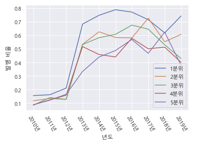

```python
from IPython.display import Image
Image("시간에따라소득에따른우울증비율그래프.png")
```

### 데이터 셋 합치기, 종속변수 0,1로 만들어주기

```python
import statsmodels.formula.api as smf
import statsmodels.api as sm
```

```python
data10['DF2_pr_needs10'] = [np.nan if b > 1 else b for b in data10['DF2_pr']]
data11['DF2_pr_needs11'] = [np.nan if b > 1 else b for b in data11['DF2_pr']]
data12['DF2_pr_needs12'] = [np.nan if b > 1 else b for b in data12['DF2_pr']]
data13['DF2_pr_needs13'] = [np.nan if b > 1 else b for b in data13['DF2_pr']]
data14['DF2_pr_needs14'] = [np.nan if b > 1 else b for b in data14['DF2_pr']]
data15['DF2_pr_needs15'] = [np.nan if b > 1 else b for b in data15['DF2_pr']]
data16['DF2_pr_needs16'] = [np.nan if b > 1 else b for b in data16['DF2_pr']]
data17['DF2_pr_needs17'] = [np.nan if b > 1 else b for b in data17['DF2_pr']]
data18['DF2_pr_needs18'] = [np.nan if b > 1 else b for b in data18['DF2_pr']]
data19['DF2_pr_needs19'] = [np.nan if b > 1 else b for b in data19['DF2_pr']]
```

```python
DF2_needs11 = pd.DataFrame(data11.dropna(subset = ['DF2_pr_needs11']))
DF2_needs12 = pd.DataFrame(data12.dropna(subset = ['DF2_pr_needs12']))
DF2_needs13 = pd.DataFrame(data13.dropna(subset = ['DF2_pr_needs13']))
DF2_needs14 = pd.DataFrame(data14.dropna(subset = ['DF2_pr_needs14']))
DF2_needs15 = pd.DataFrame(data15.dropna(subset = ['DF2_pr_needs15']))
DF2_needs16 = pd.DataFrame(data16.dropna(subset = ['DF2_pr_needs16']))
DF2_needs17 = pd.DataFrame(data17.dropna(subset = ['DF2_pr_needs17']))
DF2_needs18 = pd.DataFrame(data18.dropna(subset = ['DF2_pr_needs18']))
DF2_needs19 = pd.DataFrame(data19.dropna(subset = ['DF2_pr_needs19']))
data = pd.concat([DF2_needs11, DF2_needs12, DF2_needs13, DF2_needs14, DF2_needs15, DF2_needs16, DF2_needs17, DF2_needs18, DF2_needs19], join='outer')
```

```python
data
```

|  | mod_d | ID | year | ID_fam | region | town_t | apt_t | psu | sex | age | ... | BS12_47_2 | HE_nc | HE_insulin_etc | HE_DM_HbA1c | HE_HBsAg_etc | HE_Ucrea_etc | HE_Ualb_etc | N_FOLATE | LF_SECUR_Y | DF2_pr_needs19 |
| --- | --- | --- | --- | --- | --- | --- | --- | --- | --- | --- | --- | --- | --- | --- | --- | --- | --- | --- | --- | --- | --- |
| 2 | 2019.03.06. | A348964302 | 2011 | A3489643 | 1 | 1 | 1 | A348 | 2 | 70 | ... | NaN | NaN | NaN | NaN | NaN | NaN | NaN | NaN | NaN | NaN |
| 8 | 2019.03.06. | A348966701 | 2011 | A3489667 | 1 | 1 | 1 | A348 | 2 | 36 | ... | NaN | NaN | NaN | NaN | NaN | NaN | NaN | NaN | NaN | NaN |
| 10 | 2019.03.06. | A348968901 | 2011 | A3489689 | 1 | 1 | 1 | A348 | 2 | 63 | ... | NaN | NaN | NaN | NaN | NaN | NaN | NaN | NaN | NaN | NaN |
| 11 | 2019.03.06. | A348969101 | 2011 | A3489691 | 1 | 1 | 1 | A348 | 1 | 80 | ... | NaN | NaN | NaN | NaN | NaN | NaN | NaN | NaN | NaN | NaN |
| 18 | 2019.03.06. | A348969901 | 2011 | A3489699 | 1 | 1 | 1 | A348 | 2 | 65 | ... | NaN | NaN | NaN | NaN | NaN | NaN | NaN | NaN | NaN | NaN |
| ... | ... | ... | ... | ... | ... | ... | ... | ... | ... | ... | ... | ... | ... | ... | ... | ... | ... | ... | ... | ... | ... |
| 7967 | 2021.02.26. | R502191503 | 2019 | R5021915 | 8 | 1 | 2 | R502 | 1 | 21 | ... | 88.0 | NaN | NaN | 1.0 | NaN | NaN | NaN | NaN | NaN | 0.0 |
| 8027 | 2021.02.26. | R503290102 | 2019 | R5032901 | 8 | 2 | 1 | R503 | 2 | 56 | ... | 88.0 | 34.9 | NaN | 3.0 | NaN | NaN | NaN | 637.597400 | 1.0 | 1.0 |
| 8047 | 2021.02.26. | R503490701 | 2019 | R5034907 | 8 | 2 | 1 | R503 | 2 | 59 | ... | 88.0 | 33.9 | NaN | 2.0 | NaN | NaN | NaN | 457.043903 | 1.0 | 1.0 |
| 8097 | 2021.02.26. | R504368302 | 2019 | R5043683 | 8 | 1 | 2 | R504 | 2 | 53 | ... | 88.0 | 32.1 | NaN | 2.0 | NaN | NaN | NaN | 270.833664 | 1.0 | 1.0 |
| 8100 | 2021.02.26. | R504370002 | 2019 | R5043700 | 8 | 1 | 2 | R504 | 2 | 51 | ... | 88.0 | 31.9 | NaN | 1.0 | NaN | NaN | NaN | 584.274484 | 1.0 | 1.0 |

3581 rows × 1368 columns

# 1. 소득과 우울증간에 단순회귀모델 구성하기

```python
DFicm5_dame = smf.glm("DF2_pr ~ incm5", data = data).fit()
DFicm5_dame.params
```

```
Intercept    0.490084
incm5       -0.041935
dtype: float64
```

```python
DFicm5_dame.summary()
```

Generalized Linear Model Regression Results

| Dep. Variable: | DF2_pr | No. Observations: | 3556 |
| --- | --- | --- | --- |
| Model: | GLM | Df Residuals: | 3554 |
| Model Family: | Gaussian | Df Model: | 1 |
| Link Function: | identity | Scale: | 0.23096 |
| Method: | IRLS | Log-Likelihood: | -2439.1 |
| Date: | Tue, 08 Jun 2021 | Deviance: | 820.84 |
| Time: | 18:40:48 | Pearson chi2: | 821. |
| No. Iterations: | 3 |  |  |
| Covariance Type: | nonrobust |  |  |

|  | coef | std err | z | P>\|z\| | [0.025 | 0.975] |
| --- | --- | --- | --- | --- | --- | --- |
| Intercept | 0.4901 | 0.017 | 28.337 | 0.000 | 0.456 | 0.524 |
| incm5 | -0.0419 | 0.006 | -7.493 | 0.000 | -0.053 | -0.031 |

통계적으로도 유의미하게 상관관계가 있음을 알 수 있다

# 2. 다중회귀모델 구축

단순회귀모델은 좋은 모델이 아닐 확률이 높으므로 다양한 독립변수들을 선별하여 다중회귀모델 구축

우울증과 관련한 독립 변수를 선별하는데 '환경적 요소 선별을 통한 딥러닝 기반 우울증 분류 예측' 논문 참고 http://journal.auric.kr/kiee/XmlViewer/f397397

```python
indexname = data[(data['age']<20)].index
data.drop(indexname, inplace = True)
data
```

|  | mod_d | ID | year | ID_fam | region | town_t | apt_t | psu | sex | age | ... | BS12_47_2 | HE_nc | HE_insulin_etc | HE_DM_HbA1c | HE_HBsAg_etc | HE_Ucrea_etc | HE_Ualb_etc | N_FOLATE | LF_SECUR_Y | DF2_pr_needs19 |
| --- | --- | --- | --- | --- | --- | --- | --- | --- | --- | --- | --- | --- | --- | --- | --- | --- | --- | --- | --- | --- | --- |
| 2 | 2019.03.06. | A348964302 | 2011 | A3489643 | 1 | 1 | 1 | A348 | 2 | 70 | ... | NaN | NaN | NaN | NaN | NaN | NaN | NaN | NaN | NaN | NaN |
| 8 | 2019.03.06. | A348966701 | 2011 | A3489667 | 1 | 1 | 1 | A348 | 2 | 36 | ... | NaN | NaN | NaN | NaN | NaN | NaN | NaN | NaN | NaN | NaN |
| 10 | 2019.03.06. | A348968901 | 2011 | A3489689 | 1 | 1 | 1 | A348 | 2 | 63 | ... | NaN | NaN | NaN | NaN | NaN | NaN | NaN | NaN | NaN | NaN |
| 11 | 2019.03.06. | A348969101 | 2011 | A3489691 | 1 | 1 | 1 | A348 | 1 | 80 | ... | NaN | NaN | NaN | NaN | NaN | NaN | NaN | NaN | NaN | NaN |
| 18 | 2019.03.06. | A348969901 | 2011 | A3489699 | 1 | 1 | 1 | A348 | 2 | 65 | ... | NaN | NaN | NaN | NaN | NaN | NaN | NaN | NaN | NaN | NaN |
| ... | ... | ... | ... | ... | ... | ... | ... | ... | ... | ... | ... | ... | ... | ... | ... | ... | ... | ... | ... | ... | ... |
| 7967 | 2021.02.26. | R502191503 | 2019 | R5021915 | 8 | 1 | 2 | R502 | 1 | 21 | ... | 88.0 | NaN | NaN | 1.0 | NaN | NaN | NaN | NaN | NaN | 0.0 |
| 8027 | 2021.02.26. | R503290102 | 2019 | R5032901 | 8 | 2 | 1 | R503 | 2 | 56 | ... | 88.0 | 34.9 | NaN | 3.0 | NaN | NaN | NaN | 637.597400 | 1.0 | 1.0 |
| 8047 | 2021.02.26. | R503490701 | 2019 | R5034907 | 8 | 2 | 1 | R503 | 2 | 59 | ... | 88.0 | 33.9 | NaN | 2.0 | NaN | NaN | NaN | 457.043903 | 1.0 | 1.0 |
| 8097 | 2021.02.26. | R504368302 | 2019 | R5043683 | 8 | 1 | 2 | R504 | 2 | 53 | ... | 88.0 | 32.1 | NaN | 2.0 | NaN | NaN | NaN | 270.833664 | 1.0 | 1.0 |
| 8100 | 2021.02.26. | R504370002 | 2019 | R5043700 | 8 | 1 | 2 | R504 | 2 | 51 | ... | 88.0 | 31.9 | NaN | 1.0 | NaN | NaN | NaN | 584.274484 | 1.0 | 1.0 |

3559 rows × 1368 columns

필요한 값에 대해 데이터를 가공해주었다. (8 = 해당 없음, 9 = 무응답)

```python
data['marry'] = [0 if b == 2 else (np.nan if b == 9  else b) for b in data['marri_1']]
data['sleep'] = [np.nan if b == 8888 or b == 9999 else b for b in data['Total_slp_wk']]
data['stress'] = [np.nan if b==8 or b==9 else b for b in data['BP1']]
data['smoke'] = [np.nan if b==8 or b==9 else (0 if b==2 or b==3 else b) for b in data['BS3_1']]
data['press'] = [np.nan if b==8 or b==9 else b for b in data['DI1_pr']]
```

```python
mod_glm_marry = smf.glm(formula = 'DF2_pr ~ marry',data = data).fit()
mod_glm_slp = smf.glm(formula = 'DF2_pr ~ sleep',data = data).fit()
mod_glm_str = smf.glm(formula = 'DF2_pr ~ stress',data = data).fit()
mod_glm_chol = smf.glm(formula = 'DF2_pr ~ HE_chol',data = data).fit()
mod_glm_hb = smf.glm(formula = 'DF2_pr ~ HE_HB',data = data).fit()
mod_glm_bun = smf.glm(formula = 'DF2_pr ~ HE_BUN',data = data).fit()
mod_glm_pls = smf.glm(formula = 'DF2_pr ~ press',data = data).fit()
mod_glm_plu = smf.glm(formula = 'DF2_pr ~ HE_sbp',data = data).fit()
mod_glm_bs = smf.glm(formula = 'DF2_pr ~ smoke',data = data).fit()
```

```python
print('소득 모델 : ', DFicm5_dame.aic.round(3))
print('결혼 모델: ', mod_glm_marry.aic.round(3))
print('수면시간 모델: ', mod_glm_slp.aic.round(3))
print('스트레스 모델: ', mod_glm_str.aic.round(3))
print('콜레스테롤 모델: ', mod_glm_chol.aic.round(3))
print('헤모글로빈 모델 ', mod_glm_hb.aic.round(3))
print('신장기능 모델: ', mod_glm_bun.aic.round(3))
print('맥박 모델: ', mod_glm_pls.aic.round(3))
print('혈압 모델: ', mod_glm_plu.aic.round(3))
print('흡연 모델: ', mod_glm_bs.aic.round(3))
```

```
소득 모델 :  4882.188
결혼 모델:  4931.988
수면시간 모델:  1102.319
스트레스 모델:  4812.627
콜레스테롤 모델:  4627.328
헤모글로빈 모델  4608.06
신장기능 모델:  4626.451
맥박 모델:  1609.294
혈압 모델:  4930.63
흡연 모델:  1512.408
```

```python
null_model = smf.glm(formula = 'DF2_pr ~ 1',data = data, family = sm.families.Binomial()).fit()
iv1_model = smf.glm(formula = 'DF2_pr ~ sleep',data = data, family = sm.families.Binomial()).fit()
iv2_model = smf.glm(formula = 'DF2_pr ~ sleep + smoke',data = data, family = sm.families.Binomial()).fit()
iv3_model = smf.glm(formula = 'DF2_pr ~ sleep + smoke + press',data = data, family = sm.families.Binomial()).fit()
iv4_model = smf.glm(formula = 'DF2_pr ~ sleep + smoke + press + HE_HB',data = data, family = sm.families.Binomial()).fit()
iv5_model = smf.glm(formula = 'DF2_pr ~ sleep + smoke + press + HE_HB + HE_BUN',data = data, family = sm.families.Binomial()).fit()
iv6_model = smf.glm(formula = 'DF2_pr ~ sleep + smoke + press + HE_HB + HE_BUN + HE_chol',data = data, family = sm.families.Binomial()).fit()
```

```python
print(null_model.aic.round(3))
print(iv1_model.aic.round(3))
print(iv2_model.aic.round(3))
print(iv3_model.aic.round(3))
print(iv4_model.aic.round(3))
print(iv5_model.aic.round(3))
print(iv6_model.aic.round(3))
```

```
4710.368
1051.755
335.511
88.907
80.967
82.885
84.865
```

독립변수를 수면시간, 흡연 여부, 맥박, 헤모글로빈 농도 이 네 가지를 가지는 모델에서 AIC값이 가장 작으므로 우울증에 대한 다중회귀모델로서 가장 좋은 모델이라고 할 수 있다.

```python
iv3_model.summary()
```

Generalized Linear Model Regression Results

| Dep. Variable: | DF2_pr | No. Observations: | 71 |
| --- | --- | --- | --- |
| Model: | GLM | Df Residuals: | 67 |
| Model Family: | Binomial | Df Model: | 3 |
| Link Function: | logit | Scale: | 1.0000 |
| Method: | IRLS | Log-Likelihood: | -40.454 |
| Date: | Tue, 08 Jun 2021 | Deviance: | 80.907 |
| Time: | 18:40:49 | Pearson chi2: | 70.8 |
| No. Iterations: | 4 |  |  |
| Covariance Type: | nonrobust |  |  |

|  | coef | std err | z | P>\|z\| | [0.025 | 0.975] |
| --- | --- | --- | --- | --- | --- | --- |
| Intercept | 1.1706 | 1.479 | 0.792 | 0.429 | -1.727 | 4.068 |
| sleep | 0.0015 | 0.002 | 0.610 | 0.542 | -0.003 | 0.006 |
| smoke | -0.2819 | 0.592 | -0.476 | 0.634 | -1.442 | 0.879 |
| press | -0.6895 | 1.157 | -0.596 | 0.551 | -2.957 | 1.578 |

그러나 각 독립변수에 대한 p값을 확인해보니 0.05보다 큰 값이 나와 독립 변수로 적절하지 않다는 결과가 나왔음을 볼 수 있다.

이는 nan값이 많이 포함된 독립 변수들이 포함되다보니 해당되는 표본이 작아져 p값에 영향을 준 것으로 보인다.

# 2-1. 다중회귀모델 보정

```python
data['sex_needs'] = ['M' if b==1 else 'F' for b in data['BP1']]
data['work'] = [0 if b == 888 else (np.nan if b == 999  else b) for b in data['EC_wht_23']]
```

```python
mod_glm_age = smf.glm(formula = 'DF2_pr ~ age',data = data).fit()
mod_glm_sex = smf.glm(formula = 'DF2_pr ~ sex_needs',data = data).fit()
mod_glm_height = smf.glm(formula = 'DF2_pr ~ HE_ht',data = data).fit()
mod_glm_weight = smf.glm(formula = 'DF2_pr ~ HE_wt',data = data).fit()
mod_glm_BMI = smf.glm(formula = 'DF2_pr ~ HE_BMI',data = data).fit()
mod_glm_drink = smf.glm(formula = 'DF2_pr ~ dr_month',data = data).fit()
mod_glm_work = smf.glm(formula = 'DF2_pr ~ work',data = data).fit()
```

```python
print('소득 모델 : ', DFicm5_dame.aic.round(3))
print('결혼 모델: ', mod_glm_marry.aic.round(3))
print('스트레스 모델: ', mod_glm_str.aic.round(3))
print('나이 모델 : ', mod_glm_age.aic.round(3))
print('성별 모델: ', mod_glm_sex.aic.round(3))
print('BMI 모델: ', mod_glm_BMI.aic.round(3))
print('음주 모델: ', mod_glm_drink.aic.round(3))
print('근로 시간 모델: ', mod_glm_work.aic.round(3))
```

```
소득 모델 :  4882.188
결혼 모델:  4931.988
스트레스 모델:  4812.627
나이 모델 :  4915.61
성별 모델:  4849.487
BMI 모델:  4909.771
음주 모델:  4893.226
근로 시간 모델:  4859.298
```

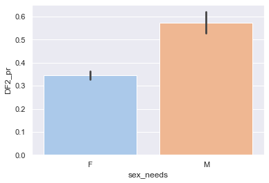

```python
sns.barplot(x = "sex_needs",y = "DF2_pr", data = data, palette='pastel')
```

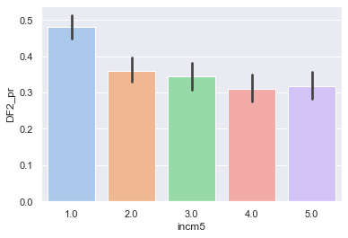

```python
sns.barplot(x = "incm5",y = "DF2_pr", data = data, palette='pastel')
```

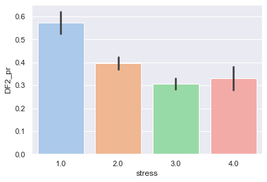

```python
sns.barplot(x = "stress",y = "DF2_pr", data = data, palette='pastel')
```

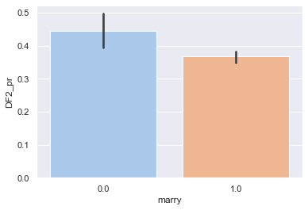

```python
sns.barplot(x = "marry",y = "DF2_pr", data = data, palette = 'pastel')
```

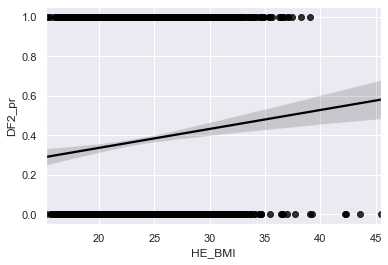

```python
sns.regplot(x = 'HE_BMI', y = 'DF2_pr', data = data, color = 'black')
```

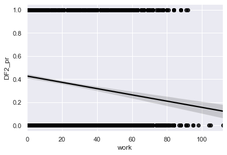

```python
sns.regplot(x = 'work', y = 'DF2_pr', data = data, color = 'black')
```

```python
null_model = smf.glm(formula = 'DF2_pr ~ 1',data = data, family = sm.families.Binomial()).fit()
cor1_model = smf.glm(formula = 'DF2_pr ~ stress',data = data, family = sm.families.Binomial()).fit()
cor2_model = smf.glm(formula = 'DF2_pr ~ stress + sex_needs',data = data, family = sm.families.Binomial()).fit()
cor3_model = smf.glm(formula = 'DF2_pr ~ stress + sex_needs + work',data = data, family = sm.families.Binomial()).fit()
cor4_model = smf.glm(formula = 'DF2_pr ~ stress + sex_needs + work + dr_month',data = data, family = sm.families.Binomial()).fit()
cor5_model = smf.glm(formula = 'DF2_pr ~ stress + sex_needs + work + dr_month + HE_BMI',data = data, family = sm.families.Binomial()).fit()
cor6_model = smf.glm(formula = 'DF2_pr ~ stress + sex_needs + work + dr_month + HE_BMI + age',data = data, family = sm.families.Binomial()).fit()
cor7_model = smf.glm(formula = 'DF2_pr ~ stress + sex_needs + work + dr_month + HE_BMI + age + marry',data = data, family = sm.families.Binomial()).fit()
full_model = smf.glm(formula = 'DF2_pr ~ stress + sex_needs + work + dr_month + HE_BMI + age + marry + incm5',data = data, family = sm.families.Binomial()).fit()
```

```python
print(null_model.aic.round(3))
print(cor1_model.aic.round(3))
print(cor2_model.aic.round(3))
print(cor3_model.aic.round(3))
print(cor4_model.aic.round(3))
print(cor5_model.aic.round(3))
print(cor6_model.aic.round(3))
print(full_model.aic.round(3))
```

```
4710.368
4587.522
4575.718
4490.365
4484.183
4459.836
4451.217
4355.413
```

```python
full_model.summary()
```

Generalized Linear Model Regression Results

| Dep. Variable: | DF2_pr | No. Observations: | 3493 |
| --- | --- | --- | --- |
| Model: | GLM | Df Residuals: | 3484 |
| Model Family: | Binomial | Df Model: | 8 |
| Link Function: | logit | Scale: | 1.0000 |
| Method: | IRLS | Log-Likelihood: | -2168.7 |
| Date: | Tue, 08 Jun 2021 | Deviance: | 4337.4 |
| Time: | 18:40:57 | Pearson chi2: | 3.51e+03 |
| No. Iterations: | 4 |  |  |
| Covariance Type: | nonrobust |  |  |

|  | coef | std err | z | P>\|z\| | [0.025 | 0.975] |
| --- | --- | --- | --- | --- | --- | --- |
| Intercept | -0.1592 | 0.329 | -0.484 | 0.628 | -0.804 | 0.485 |
| sex_needs[T.M] | 0.4116 | 0.149 | 2.760 | 0.006 | 0.119 | 0.704 |
| stress | -0.3412 | 0.064 | -5.358 | 0.000 | -0.466 | -0.216 |
| work | -0.0107 | 0.002 | -6.237 | 0.000 | -0.014 | -0.007 |
| dr_month | -0.1242 | 0.079 | -1.564 | 0.118 | -0.280 | 0.031 |
| HE_BMI | 0.0340 | 0.010 | 3.371 | 0.001 | 0.014 | 0.054 |
| age | 0.0169 | 0.003 | 5.754 | 0.000 | 0.011 | 0.023 |
| marry | -0.7474 | 0.142 | -5.270 | 0.000 | -1.025 | -0.469 |
| incm5 | -0.1558 | 0.026 | -6.043 | 0.000 | -0.206 | -0.105 |

```python
fin_model = smf.glm(formula = 'DF2_pr ~ stress + sex_needs + work + HE_BMI + age + marry + incm5', data = data, family = sm.families.Binomial()).fit()
fin_model.summary()
```

Generalized Linear Model Regression Results

| Dep. Variable: | DF2_pr | No. Observations: | 3496 |
| --- | --- | --- | --- |
| Model: | GLM | Df Residuals: | 3488 |
| Model Family: | Binomial | Df Model: | 7 |
| Link Function: | logit | Scale: | 1.0000 |
| Method: | IRLS | Log-Likelihood: | -2170.9 |
| Date: | Tue, 08 Jun 2021 | Deviance: | 4341.9 |
| Time: | 18:40:59 | Pearson chi2: | 3.51e+03 |
| No. Iterations: | 4 |  |  |
| Covariance Type: | nonrobust |  |  |

|  | coef | std err | z | P>\|z\| | [0.025 | 0.975] |
| --- | --- | --- | --- | --- | --- | --- |
| Intercept | -0.2666 | 0.323 | -0.826 | 0.409 | -0.899 | 0.366 |
| sex_needs[T.M] | 0.4191 | 0.149 | 2.812 | 0.005 | 0.127 | 0.711 |
| stress | -0.3389 | 0.064 | -5.320 | 0.000 | -0.464 | -0.214 |
| work | -0.0111 | 0.002 | -6.535 | 0.000 | -0.014 | -0.008 |
| HE_BMI | 0.0343 | 0.010 | 3.395 | 0.001 | 0.014 | 0.054 |
| age | 0.0178 | 0.003 | 6.149 | 0.000 | 0.012 | 0.023 |
| marry | -0.7375 | 0.142 | -5.206 | 0.000 | -1.015 | -0.460 |
| incm5 | -0.1569 | 0.026 | -6.091 | 0.000 | -0.207 | -0.106 |

# 재미로 보는 나의 우울증 확률

기혼:1, 미혼:0 입력

소득분위에 대해서는 인터넷 기준 참고

#### ex1) 개그우먼 이영자님

```python
user_age = input('만나이: ')
user_sex = input('성별: ')
user_work = input('근로 시간: ')
user_BMI = input('BMI: ')
user_marry = input('결혼 여부: ')
user_incm5 = input('소득분위: ')
user_stress = input('스트레스 여부: ')
```

```
만나이: 53
성별: 1
근로 시간: 41.6
BMI: 28.72
결혼 여부: 0
소득분위: 5
스트레스 여부: 1
```

```python
result = fin_model.params[0] + fin_model.params[1] * float(user_sex) + fin_model.params[2] * float(user_stress) + fin_model.params[3] * float(user_work) + fin_model.params[4] * float(user_BMI) + fin_model.params[5] * float(user_marry) + fin_model.params[6] * float(user_incm5)
print(result)
```

```
-3.3509487422800386
```

```python
y = 1 / (1 + np.exp(-result))
print(y)
```

```
0.03386411011176931
```

```python
print("당신이 우울증일 확률은 " +str(int(y*100))+ "% 입니다.")
```

```
당신이 우울증일 확률은 3% 입니다.
```

#### ex2) 개그맨 유재석님

```python
user_age = input('만나이: ')
user_sex = input('성별: ')
user_work = input('근로 시간: ')
user_BMI = input('BMI: ')
user_marry = input('결혼 여부: ')
user_incm5 = input('소득분위: ')
user_stress = input('스트레스 여부: ')
```

```
만나이: 48
성별: 0
근로 시간: 42.8
BMI: 20.52
결혼 여부: 1
소득분위: 5
스트레스 여부: 1
```

```python
result = fin_model.params[0] + fin_model.params[1] * float(user_sex) + fin_model.params[2] * float(user_stress) + fin_model.params[3] * float(user_work) + fin_model.params[4] * float(user_BMI) + fin_model.params[5] * float(user_marry) + fin_model.params[6] * float(user_incm5)
print(result)
```

```
-4.046522740933666
```

```python
y = 1 / (1 + np.exp(-result))
print(y)
```

```
0.017182656745040208
```

```python
print("당신이 우울증일 확률은 " +str(int(y*100))+ "% 입니다.")
```

```
당신이 우울증일 확률은 1% 입니다.
```

#### ex3) 우리학과 평균

```python
user_age = input('만나이: ')
user_sex = input('성별: ')
user_work = input('근로 시간: ')
user_BMI = input('BMI: ')
user_marry = input('결혼 여부: ')
user_incm5 = input('소득분위: ')
user_stress = input('스트레스 여부: ')
```

```
만나이: 20
성별: 1
근로 시간: 16
BMI: 21
결혼 여부: 0
소득분위: 3
스트레스 여부: 1
```

```python
result = fin_model.params[0] + fin_model.params[1] * float(user_sex) + fin_model.params[2] * float(user_stress) + fin_model.params[3] * float(user_work) + fin_model.params[4] * float(user_BMI) + fin_model.params[5] * float(user_marry) + fin_model.params[6] * float(user_incm5)
print(result)
```

```
-1.8566987529167465
```

```python
y = 1 / (1 + np.exp(-result))
print(y)
```

```
0.1350883034094197
```

```python
print("당신이 우울증일 확률은 " +str(int(y*100))+ "% 입니다.")
```

```
당신이 우울증일 확률은 13% 입니다.
```